# Fitting ridge and lasso regressions on gene expression data

Jarod Barnhart

5/30/2022

The data we will be using in this project is gene expression data, where we are looking to develop a model that will be used to predict tumor type. Tumor type is a multi-class outcome variable and because there are many more gene variables than there are samples we must use Ridge and Lasso regression to model it. The possible tumor types are BRCA, COAD, KIRC, LUAD, and PRAD.

After loading in a few packages, defining a few useful functions we read in the data:

```r
genes<-read.csv('data/gene_data.csv',header=T)

colnames(genes)[1]<-'sample'
genes_sample<-genes[,1]
genes_no_sample<-genes[,-1]
```

We separate the the gene data into two dataframes, one of just the labels of each sample, and one of the actual data. This will make using some functions later easier.

One of the assumptions of the models we will be building is a lack of zero or small variance columns. So we find any columns like this and remove them from our model. Small variance columns can lead us to believe that those columns have more impact than they actually do. Zero variance columns actually make it impossible to run a these models, so they must be removed. Also, we standardize our data. Lasso and Ridge regression requires that each variable be centered and reduced, therefore we standardize.

```r
## Removing small variance and zero columns
genes_removed<-removeZeroVar(genes_no_sample)
genes_removed<-removeSmallVar(genes_removed)

## standardizing
genes_removed<-standardize(genes_removed)

genes_removed_sample<-data.frame(genes_sample,genes_removed)
colnames(genes_removed_sample)[1] <- 'sample'

labels<-read.csv('data/gene_labels.csv',header=T)
colnames(labels)[1]<-'sample'
labels[,2]<-as.factor(labels[,2])
labels[,2]<-as.numeric(labels[,2])

## merging
gene_data<-merge(labels,genes_removed_sample,by='sample')
```

After standardizing our data, we separate it into training and validation sets.

```r
## training and testing
smp_size2 <- floor(0.75*nrow(gene_data))
set.seed(1337)
gene_ind<-sample(seq_len(nrow(gene_data)), size = smp_size2)
gene_train <- gene_data[gene_ind, ]
gene_test <- gene_data[-gene_ind,]
```

Then we separate the training and validation data into their respective predictor and response vectors. This makes it easier to run them through the functions.

```r
# Split the training and testing data into predictors and response
xtrain<-as.matrix(gene_train[,-c(1,2)])
ytrain<-gene_train[,2]
xtest<-as.matrix(gene_test[,-c(1,2)])
ytest<-gene_test[,2]
```

## Ridge Regression

Now, we use 10-fold cross validation to find our optimal lambda value for our ridge regression.

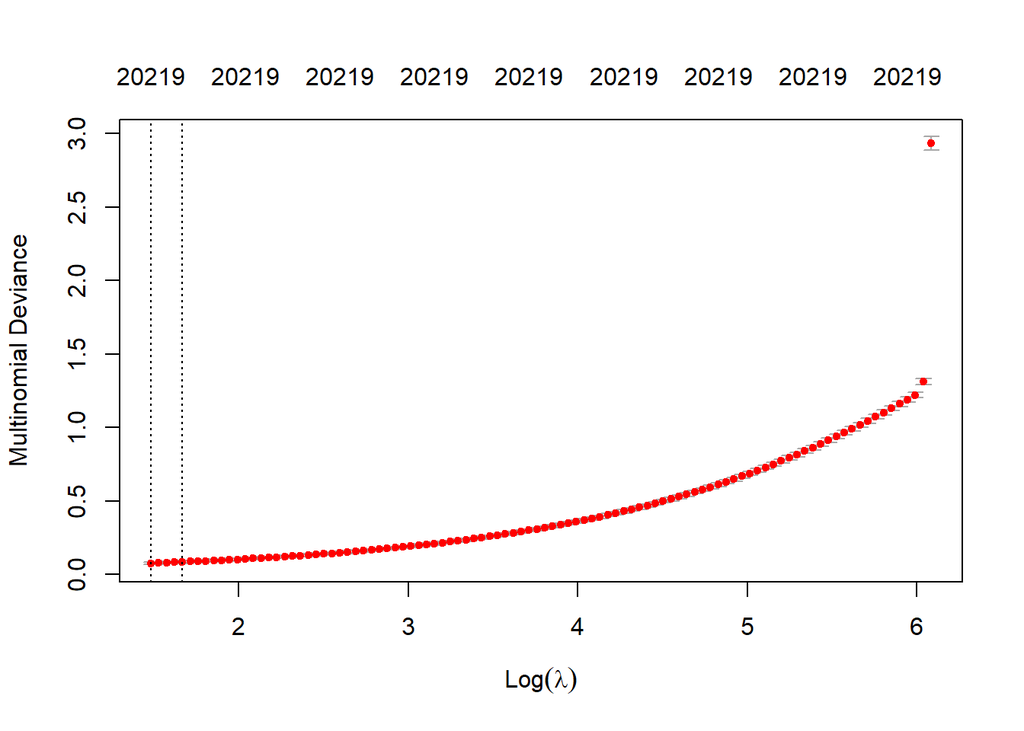

```r
## Cross-validating glm models to get optimal lambda
cv_fit <- cv.glmnet(xtrain, ytrain, alpha=0,nfolds = 10,family='multinomial')
lambda<-cv_fit$lambda.min ##optimal lambda is 4.3942
plot(cv_fit)
```

From our cross validation, we find that the optimal lambda value is 4.3942, so we make our model using the optimal lambda.

```r
## making new ridge model using optimal lambda
ridge<-glmnet(xtrain,ytrain,lambda=lambda,alpha=0,family='multinomial')
```

We take the predictions from our model, classifying the prediction based on the largest probability returned from the model. This helps us make the confusion matrix.

```r
## making the predictions from the model, classifying based on largest probability
pred_train_ridge<-as.numeric(predict(ridge,s=lambda,newx=xtrain,type='class'))
pred_test_ridge<-as.numeric(predict(ridge,s=lambda,newx=xtest,type='class'))
```

Now we make the confusion matrices for the training and validation sets.

```r
## making confusion matrices
confusion.glmnet(ridge, newx=xtrain, newy=ytrain)
```

```
##          True
## Predicted   1  2   3   4   5 Total
##     1     224  0   0   0   0   224
##     2       0 59   0   0   0    59
##     3       0  0 107   0   0   107
##     4       0  0   0 107   0   107
##     5       0  0   0   0 103   103
##     Total 224 59 107 107 103   600
##
##  Percent Correct:  1
```

```r
confusion.glmnet(ridge, newx=xtest,newy=ytest)
```

```
##          True
## Predicted  1  2  3  4  5 Total
##     1     76  0  0  0  0    76
##     2      0 19  0  0  0    19
##     3      0  0 39  0  0    39
##     4      0  0  0 34  0    34
##     5      0  0  0  0 33    33
##     Total 76 19 39 34 33   201
##
##  Percent Correct:  1
```

From the confusion matrices, we can see that these models have predicted perfectly. This obviously won’t be the case in any case using real data.

## Lasso Regression

Now, we fit a Lasso Regression to the data First, we begin with the 10-fold cross validation to find the optimal parameter

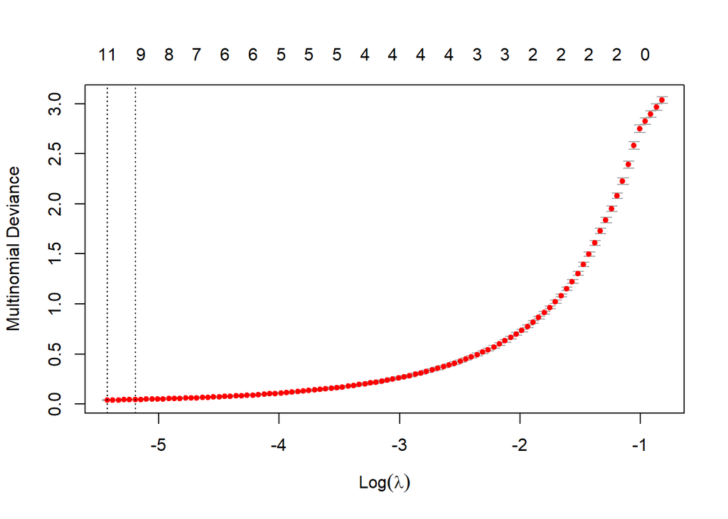

```r
cv_lasso<-cv.glmnet(x=xtrain,y=ytrain,alpha=1,nfolds=10,family='multinomial')
plot(cv_lasso)
```

Now we make the new lasso regression using the optimal parameter.

```r
lambdalasso<-cv_lasso$lambda.min
lasso<-glmnet(x=xtrain,y=ytrain,alpha=1,family='multinomial',lambda=lambdalasso)
```

And finally, we take our predictions, and make our confusion matrices.

```r
pred_train_lasso<-as.numeric(predict(lasso,s=lambdalasso,newx=xtrain,type='class'))
pred_test_lasso<-as.numeric(predict(lasso,s=lambdalasso,newx=xtest,type='class'))

confusion.glmnet(lasso, newx=xtrain,newy=ytrain)
```

```
##          True
## Predicted   1  2   3   4   5 Total
##     1     224  0   0   0   0   224
##     2       0 59   0   0   0    59
##     3       0  0 107   0   0   107
##     4       0  0   0 107   0   107
##     5       0  0   0   0 103   103
##     Total 224 59 107 107 103   600
##
##  Percent Correct:  1
```

```r
confusion.glmnet(lasso, newx=xtest,newy=ytest)
```

```
##          True
## Predicted  1  2  3  4  5 Total
##     1     76  0  1  0  0    77
##     2      0 19  0  0  0    19
##     3      0  0 38  0  0    38
##     4      0  0  0 34  0    34
##     5      0  0  0  0 33    33
##     Total 76 19 39 34 33   201
##
##  Percent Correct:  0.995
```

We can see that in the lasso testing, there is 1 sample that the lasso model predicts incorrectly, but I think if we really wanted to test these two models, we would need some new data.

From the Lasso model, we can actual see the most relevant genes for the different classes of tumor.

For the BRCA class:

```r
lasso_coefs_BRCA=(coef(cv_lasso,s='lambda.1se')$'1')[-1]
BRCA_nonzero_coefs=which(lasso_coefs_BRCA!=0)
selected_BRCA_values=lasso_coefs_BRCA[BRCA_nonzero_coefs]
selected_BRCA_names=names(gene_data)[BRCA_nonzero_coefs]
df_BRCA=data.frame(BRCA_related_gene=selected_BRCA_names,coef_val=selected_BRCA_values)
print(df_BRCA)
```

```
##    BRCA_related_gene    coef_val
## 1          gene_5576  0.36604927
## 2          gene_6746 -0.17461975
## 3          gene_6874  0.49106779
## 4          gene_7962 -0.98712859
## 5          gene_8596  0.03482932
## 6         gene_11492  0.04940506
## 7         gene_14090  0.41523169
## 8         gene_15587  0.17470311
## 9         gene_17799 -0.56617132
## 10        gene_18463  0.03339914
## 11        gene_18744  0.08465577
```

COAD Class:

```r
lasso_coefs_COAD=(coef(cv_lasso,s='lambda.1se')$'2')[-1]
COAD_nonzero_coefs=which(lasso_coefs_COAD!=0)
selected_COAD_values=lasso_coefs_COAD[COAD_nonzero_coefs]
selected_COAD_names=names(gene_data)[COAD_nonzero_coefs]
df_COAD=data.frame(COAD_related_gene=selected_COAD_names,coef_val=selected_COAD_values)
print(df_COAD)
```

```
##   COAD_related_gene  coef_val
## 1         gene_2035 0.5093988
## 2         gene_3521 0.9116147
## 3         gene_7236 0.2069242
## 4        gene_10458 0.3240117
```

4 Most relevant genes are 2035, 3521, 7236, 10458

KIRC Class:

```r
lasso_coefs_KIRC=(coef(cv_lasso,s='lambda.1se')$'3')[-1]
KIRC_nonzero_coefs=which(lasso_coefs_KIRC!=0)
selected_KIRC_values=lasso_coefs_KIRC[KIRC_nonzero_coefs]
selected_KIRC_names=names(gene_data)[KIRC_nonzero_coefs]
df_KIRC=data.frame(KIRC_related_gene=selected_KIRC_names,coef_val=selected_KIRC_values)
print(df_KIRC)
```

```
##   KIRC_related_gene     coef_val
## 1           gene_16  0.017302756
## 2          gene_217  0.946816378
## 3          gene_218  0.163330260
## 4         gene_4271  0.008398284
## 5         gene_6731  0.127745911
## 6        gene_12806 -0.042858381
## 7        gene_13816  0.488349733
## 8        gene_14112  0.203494759
## 9        gene_16244  0.341319000
```

LUAD Class:

```r
lasso_coefs_LUAD=(coef(cv_lasso,s='lambda.1se')$'4')[-1]
LUAD_nonzero_coefs=which(lasso_coefs_LUAD!=0)
selected_LUAD_values=lasso_coefs_LUAD[LUAD_nonzero_coefs]
selected_LUAD_names=names(gene_data)[LUAD_nonzero_coefs]
df_LUAD=data.frame(LUAD_related_gene=selected_LUAD_names,coef_val=selected_LUAD_values)
print(df_LUAD)
```

```
##    LUAD_related_gene      coef_val
## 1          gene_4629  0.0250940851
## 2          gene_6759  0.0306713067
## 3          gene_8314  0.1352917126
## 4          gene_9711  0.0963820563
## 5          gene_9926  0.1628372869
## 6         gene_13297  0.0659907963
## 7         gene_15893  1.0387089960
## 8         gene_15896  0.8756578785
## 9         gene_17068  0.1328748813
## 10        gene_17392  0.0236064821
## 11        gene_17778 -0.0003806741
## 12        gene_18617  0.0503625907
```

PRAD Class:

```r
lasso_coefs_PRAD=(coef(cv_lasso,s='lambda.1se')$'5')[-1]
PRAD_nonzero_coefs=which(lasso_coefs_PRAD!=0)
selected_PRAD_values=lasso_coefs_PRAD[PRAD_nonzero_coefs]
selected_PRAD_names=names(gene_data)[PRAD_nonzero_coefs]
df_PRAD=data.frame(PRAD_related_gene=selected_PRAD_names,coef_val=selected_PRAD_values)
print(df_PRAD)
```

```
##   PRAD_related_gene   coef_val
## 1         gene_3735 0.36437787
## 2         gene_9173 0.95643889
## 3         gene_9174 0.39336974
## 4        gene_12846 0.10489209
## 5        gene_13974 0.09617101
## 6        gene_18133 0.48629334
```

Out of curiosity, lets make a new model out of just the relevant genes. We start by filtering our data to just the genes we deemed relevant, along with the sample name and the class.

```r
most_relevant_genes<-c('gene_5576', 'gene_6746', 'gene_6874', 'gene_7962',
                       'gene_2035', 'gene_3521', 'gene_7236', 'gene_10458',
                       'gene_16', 'gene_217', 'gene_218', 'gene_4271',
                       'gene_4629', 'gene_6759', 'gene_8314', 'gene_9711',
                       'gene_3735', 'gene_9173', 'gene_9174', 'gene_12846')
reduced_data_train<-gene_train[,c('sample','Class',most_relevant_genes)]
reduced_data_test<-gene_test[,c('sample','Class',most_relevant_genes)]
```

```r
# Split the training and testing data into predictors and response
x_reduced_train<-as.matrix(reduced_data_train[,-c(1,2)])
y_reduced_train<-reduced_data_train[,2]
x_reduced_test<-as.matrix(reduced_data_test[,-c(1,2)])
y_reduced_test<-reduced_data_test[,2]
```

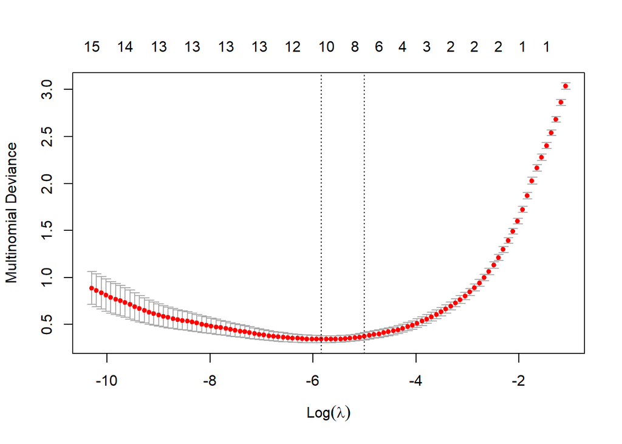

```r
cv_lasso_reduced<-cv.glmnet(x=x_reduced_train,y=y_reduced_train,alpha=1,
                            nfolds=10,family='multinomial')
plot(cv_lasso_reduced)
```

```r
lambda_lasso_reduced<-cv_lasso_reduced$lambda.min
lasso_reduced<-glmnet(x=x_reduced_train,y=y_reduced_train,alpha=1,
                      family='multinomial', lambda=lambda_lasso_reduced)
```

```r
pred_train_lasso_reduced<-as.numeric(predict(lasso_reduced,s=lambda_lasso_reduced,
                                            newx=x_reduced_train, type='class'))
pred_test_lasso_reduced<-as.numeric(predict(lasso_reduced,s=lambda_lasso_reduced,
                                            newx=x_reduced_test,type='class'))

confusion.glmnet(lasso_reduced, newx=x_reduced_train,newy=y_reduced_train)
```

```
##          True
## Predicted   1  2   3   4   5 Total
##     1     219  1   1   5   0   226
##     2       2 56   1   2   0    61
##     3       0  1 105   0   0   106
##     4       3  1   0 100   0   104
##     5       0  0   0   0 103   103
##     Total 224 59 107 107 103   600
##
##  Percent Correct:  0.9717
```

```r
confusion.glmnet(lasso_reduced, newx=x_reduced_test,newy=y_reduced_test)
```

```
##          True
## Predicted  1  2  3  4  5 Total
##     1     72  0  1  3  0    76
##     2      1 19  0  0  0    20
##     3      1  0 36  0  0    37
##     4      2  0  2 31  0    35
##     5      0  0  0  0 33    33
##     Total 76 19 39 34 33   201
##
##  Percent Correct:  0.9502
```

In a lasso regression using only the most relevant genes, we can see that on testing data, we are still getting a 95% correct model, which is fantastic.